# ripper

Samuel Cardenete

4/2/2019

## Preprocesamiento

Técnicas preprocesamiento Ripper (…)

Valores perdidos:

Número de instancias con más de un valor perdido:

```r
nrow(datos[which(numero_na>1),])
```

```
## [1] 0
```

Como vemos en nuestro conjunto de datos, no tenemos ninguna instancia con más de un valor perdido, pero si que tenemos muchas instancias con un valor perdido, en total:

```r
nrow(datos[which(numero_na==1),])
```

```
## [1] 1366
```

Como vemos se trata de un número considerable de valores perdidos. En resumen tenemos que el 15% de nuestro conjunto de datos de entrenamiento posee valores perdidos, pero como todos sabemos, una imagen vale más que mil palabras, asi que realicemos un análisis gráfico de los valores perdidos:

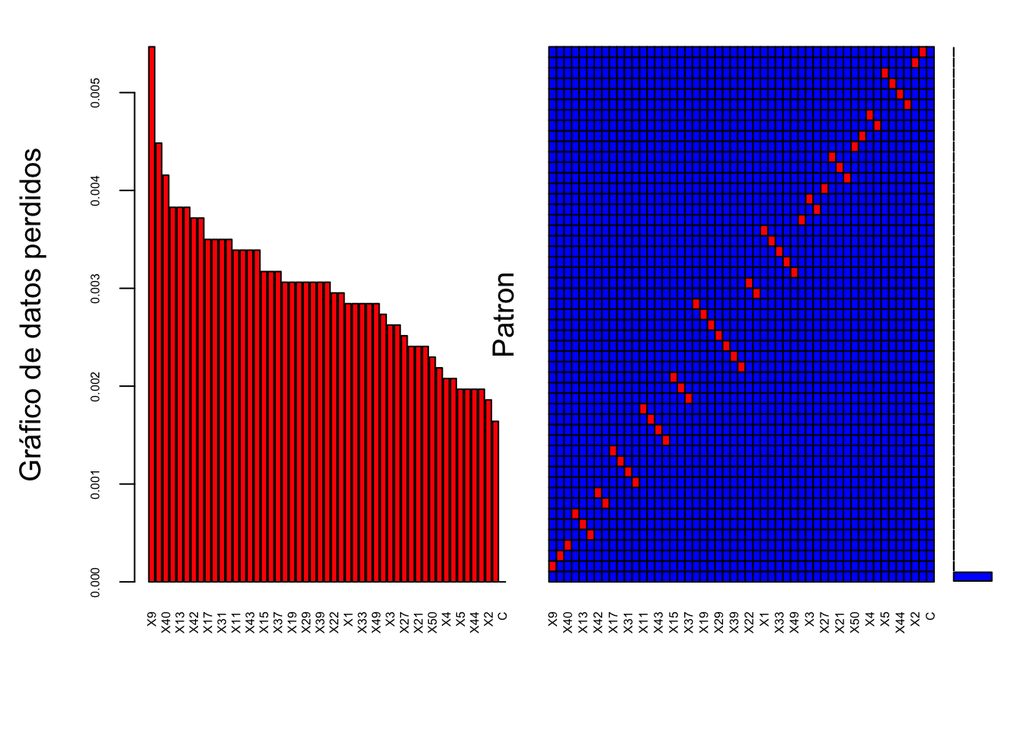

```
##
##  Variables sorted by number of missings:
##  Variable       Count
##        X9 0.005468066
##       X32 0.004483815
##       X40 0.004155731
##        X6 0.003827647
##       X13 0.003827647
##       X41 0.003827647
##       X42 0.003718285
##       X48 0.003718285
##       X17 0.003499563
##       X26 0.003499563
##       X31 0.003499563
##       X38 0.003499563
##       X11 0.003390201
##       X23 0.003390201
##       X43 0.003390201
##       X47 0.003390201
##       X15 0.003171479
##       X30 0.003171479
##       X37 0.003171479
##       X16 0.003062117
##       X19 0.003062117
##       X20 0.003062117
##       X29 0.003062117
##       X34 0.003062117
##       X39 0.003062117
##       X45 0.003062117
##       X22 0.002952756
##       X24 0.002952756
##        X1 0.002843395
##       X10 0.002843395
##       X33 0.002843395
##       X35 0.002843395
##       X49 0.002843395
##        X8 0.002734033
##        X3 0.002624672
##       X12 0.002624672
##       X27 0.002515311
##       X18 0.002405949
##       X21 0.002405949
##       X28 0.002405949
##       X50 0.002296588
##       X36 0.002187227
##        X4 0.002077865
##        X7 0.002077865
##        X5 0.001968504
##       X14 0.001968504
##       X44 0.001968504
##       X46 0.001968504
##        X2 0.001859143
##       X25 0.001640420
##         C 0.000000000
```

Además, si observamos la segunda gráfica, podemos ver la independencia entre la aparición de valores perdidos entre variables, de forma que la aparición de un valor perdido en una variable, no implica la aparición de valores perdidos en otros.

Esto requiere sin duda un análisis más exahustivo de los valores perdidos así como posible imputación. Para ello emplearemos el algoritmo de imputación *MICE*. Comencemos obteniendo el patrón de aparición de los datos perdidos:

```r
patron = mice::md.pattern(x = datos)
```

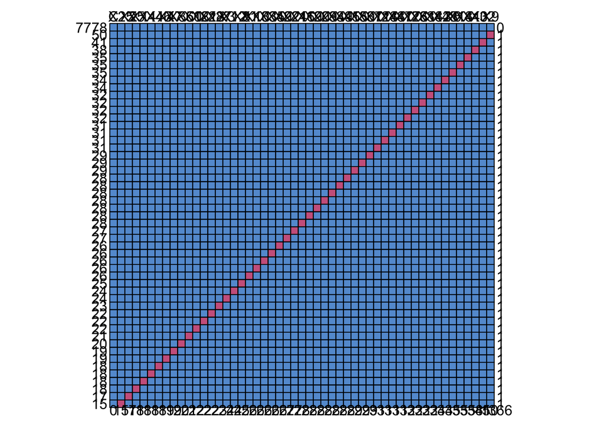

```r
#corrplot(cor(train))
```

## Ripper

Generación de modelos RIPPER (…)